formato código negrita **negrita** **negrita** italica *italica* *italica* tachado tachado

Podemos hacer una lista con viñetas (*,-,+)siempre hay que dejar una linea en blanco para ponder con vinietas

- negrita con asteriscos dobles
- italica con guiones bajos
- código con comillas hacia atrás (backticks)

Se puede usar una lista numerada usando solo número y ni siquiera hay que poner numeros consecutivos:

1. negrita con asteriscos dobles
2. italica con guiones bajos
3. código con comillas hacia atrás (backticks)

Podes hacer titulos de sección de diferentes tamaños iniciando una linea con algún número de simbolos #:

# Título

## Sección principal

### Sub-sección

#### Sub-sub sección

Podés mostrar un hipervínculo así:

[texto a mostar](http://el-sitio-web.com) #la direccion web sola se va siempre a mostrar con vinvulo#

Podés poner subíndices (e.g., F2) con F<sub>2</sub> y superíndices (e.g., F2) con F<sup>2</sup>.

Sí sabés escribir ecuaciones con LaTeX, podes usar $ $ y para insertar ecuaciones como $E = mc^2$ E=mc2

# 1 $ dentro del parrafo, 2 $$ fuera del parrafo

$$y = \mu + \sum_{i=1}^p \beta_i x_i + \epsilon$$

Hay editores online https://www.codecogs.com/latex/eqneditor.php

Ejercicio 2 Añade fragmentos de código para

cargar el paquete ggplot2  
leer los datos de gapminder crear un gráfico

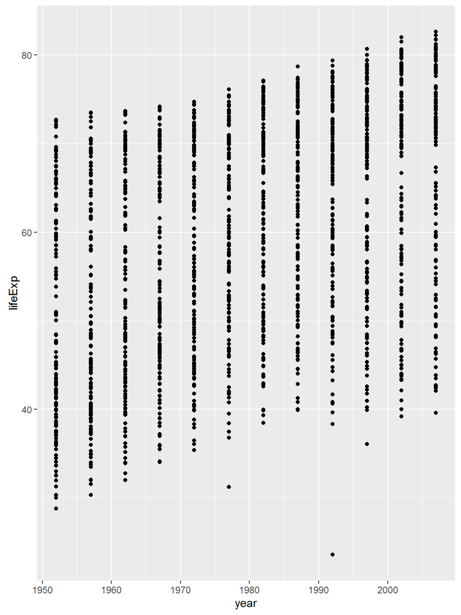

echo false para no ver el comando.

results hide, no muestra nada del resultado Usa eval=FALSE para mostrar el código pero no evaluarlo.

Usa warning=FALSE y message=FALSE para esconder las advertencias y mensajes.

Usa fig.height y fig.width para controlar el tamaño de la figuras (en pulgadas)

Muchas veces vas a querer usar algunas opciones en todos los fragmentos. Para esto, podés configurar opciones globales:

el codigo que pongo tiene qu estar una linea abajo de la opcion de r

fig: donde quiero guardar las figuras, importante la / para decirle que es un directorio

odés hacer cada número en tu reporte reproducible.

Usa: ## para fragmento de código en línea, así: 30.22. El código va a ser ejectuado y reemplazado con el valor del resultado. todas las comillas tienen que estar en un misma linea

No dejes que los fragmentos en línea se separen entre línas

include false equivale a echo false y results hide

# texto en linea

-4.35